# Basic statistics - t-test

Elizabeth Oladapo

Last modified: 2 September 2023

In part 1 of this course, you have acquired skills in data manipulation and graph creation. You should now feel confident in using dplyr functions like select() and filter(), employing the %>% pipe operator to sequence actions, employing group_by() and summarise() to generate summary statistics from your data, and utilizing ggplot() to generate a wide range of graphs, including scatterplots, histograms, boxplots, and graphs showing means with standard error bars.

In this section, we will focus on enhancing your understanding of conducting statistical analyses to address questions and draw robust conclusions from your dataset.

### **What to expect**

Throughout this section, you will:

Import and explore the data: Begin by importing and exploring the dataset. Utilize histogram visualizations and various summary statistics to gain insights into the assumptions underlying the implementation of a t-test.

Implement a t-test: Learn how to execute a t-test, which is a statistical method used to compare means between two groups.

Interpret the t-test output: Develop the skills to interpret the results of the t-test. This includes understanding concepts such as confidence intervals, null hypotheses, and p-values. These concepts are essential for drawing meaningful conclusions from your analysis.

By the end of this section, you will have a grasp of how to conduct a t-test, assess its outcomes, and apply key statistical concepts like confidence intervals, null hypotheses, and p-values in your data analysis.

To proceed, load the “tidyverse” library, which includes both “ggplot” and “dplyr.” To import the “gpa.csv” data, we will use the “read.csv” function. You may also notice that we use “glimpse” to inspect the data. Additionally, we can include “str” to further examine the data structure.

```r
# Load the tidyverse library, including ggplot2 and dplyr
library(tidyverse)
# Import the data from the specified path
gpa <- read.csv("data/gpa.csv")

# Examine the data structure using glimpse and str
glimpse(gpa)
```

```
## Rows: 32
## Columns: 5
## $ gpa        <dbl> 3.400, 3.500, 3.500, 3.500, 3.600, 3.700, 3.700, 3.800, 3.6~
## $ studyweek  <int> 42, 12, 30, 25, 10, 15, 4, 2, 21, 20, 20, 25, 7, 15, 10, 30~
## $ sleepnight <dbl> 9.0, 8.0, 8.0, 8.0, 6.0, 7.0, 5.0, 8.0, 9.0, 6.0, 7.0, 5.0,~
## $ out        <dbl> 2.0, 2.0, 3.0, 2.0, 4.0, 1.5, 1.0, 4.0, 3.0, 2.0, 1.0, 1.0,~
## $ gender     <chr> "male", "male", "male", "male", "male", "male", "male", "ma~
```

```r
str(gpa)
```

```
## 'data.frame':    32 obs. of  5 variables:
##  $ gpa       : num  3.4 3.5 3.5 3.5 3.6 3.7 3.7 3.8 3.65 3.65 ...
##  $ studyweek : int  42 12 30 25 10 15 4 2 21 20 ...
##  $ sleepnight: num  9 8 8 8 6 7 5 8 9 6 ...
##  $ out       : num  2 2 3 2 4 1.5 1 4 3 2 ...
##  $ gender    : chr  "male" "male" "male" "male" ...
```

### **Data analysis pipeline**

**Careful Experiment Design:** Begin by designing your experiment or sampling program meticulously, with utmost attention to the specific question you aim to address. Your choice of measurements should align with relevant theories and concepts. You will have a response variable (also known as the dependent variable), representing the y-axis in your graphs, and one or more explanatory variables (also known as independent variables) representing the x-axis and grouping variables.

**Replication and Randomization:** Ensure proper replication and randomization in your experiment or sampling design. Neglecting this crucial step renders your data essentially useless. Statistics cannot remedy this issue.

**Creating Visualizations:** The initial step in data analysis involves creating a figure, rather than conducting an analysis. Your primary objective is to take the idea you conceived (as mentioned in step 1) and visualize the patterns within your data. Your response and explanatory variables correspond to the y-axis, x-axis, and grouping variables. Utilize ggplot() and faceting to produce visual representations that align with your research question.

**Model Building and Fitting:** The subsequent step entails constructing and fitting a model to your data. We will introduce various modeling strategies in the subsequent sessions.

**Assumption Evaluation:** The third step involves evaluating the assumptions associated with fitting the model. This process does not solely revolve around determining the significance of p-values. For most models, it centers on assessing the distribution of residuals, which represent the variation around the model fit. We will delve deeper into this topic as we progress.

**Inference Using the Model:** The fourth step entails making inferences using the model. Assuming our assumptions hold, we can begin examining the t-, F-, or other test statistics along with their associated p-values.

**Revisiting Visualizations:** Finally, the fifth step involves revisiting the initial graph. Occasionally, enhancing the graph with text derived from the statistics (e.g., as discussed in step 6) is necessary. In some instances, it may involve incorporating the fitted or predicted values from the model and overlaying them onto the raw data visualization.

The dataset we are about to work with has been set up fairly well. However, it is critical to know that without robust study designs, which include randomization and replication, data quality may suffer. Statistics alone cannot remedy this.

Before diving into data analysis:

1. It is essential to pause and reflect on two fundamental questions: “What is the question?” and “Why is it interesting?”
2. It’s crucial to have a clear understanding of your expectations. You should know the response variable you are attempting to predict or explain.
3. Grasp the concept of explanatory variables – these are the factors you believe influence the response variable that holds your interest.

***Always prioritize creating visual representations of your data. The initial step in any data analysis journey is data exploration, which involves visualizing the dataset to make assumptions. Only after data visualization should you proceed to construct the model for evaluating your research question.

### **Make assumptions**

Again, the initial step involves visualizing the data, and I recommend using a histogram as an effective means to assess the characteristics of the dataset you intend to use for your analysis.

Histograms give us idea of the distribution of the variable. Create a histogram of the data in the “gpa” dataset and by visual observation, make an assumption about the response variable being normally distributed (which is an assumption for a t-test) and the relationship between and withing the groups of predictors.

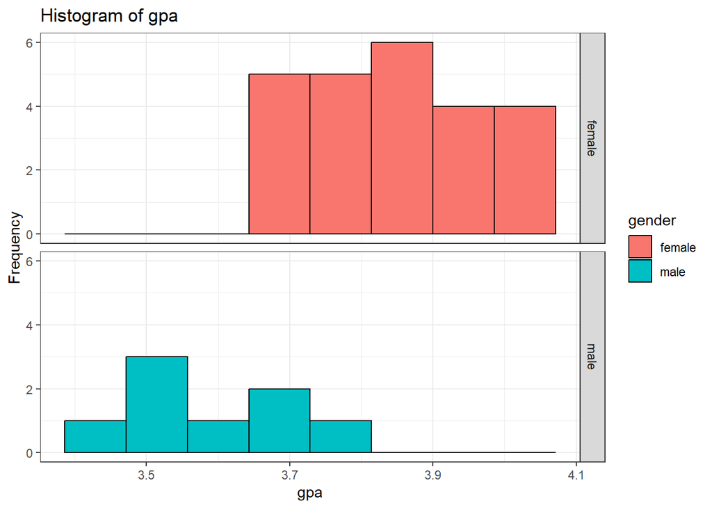

```r
ggplot(data = gpa,aes(x = gpa, fill = gender)) +
  geom_histogram(bins = 8, color = "black") +
  labs(title = "Histogram of gpa", x = "gpa", y = "Frequency")+
  facet_grid(gender~.)+
  theme_bw()
```

The distribution of the response variable looks roughly normal (bell curve shape) and we will take the normal distribution as our assumption

### **Check the assumptions**

Check your assumptions with statistical analysis, by calculating the means and variances.

Our initial visual check suggests the possibility of detecting a significant difference. We noted that there is substantial variability within each of these data groups, and there is also overlap between them. Let us proceed to calculate the means and variances. We will accomplish this using the “group by” and “summarize” functions.

Why are we interested in calculating the means? The primary reason is to assess whether there exists a significant difference between these means. We will delve into this concept further as we progress through the exercise. Our focus is on determining whether the disparity between the means is substantial. If the two distributions are notably separated, the means will exhibit a considerable difference. Conversely, if the distributions completely overlap, the means will be identical, resulting in a minimal difference between them.

Why may we be interested in calculating the variance? One of the fundamental assumptions underlying the traditional t.test is the equality of variances. Therefore, it is crucial for us to calculate the variances. Later on, we will discuss instances where we might be able to overlook this assumption and why it is still valuable to calculate variances.

```r
gpa_sum_dat <- gpa %>%
  group_by(gender) %>%
  summarize(
    mean_gpa = mean(gpa),
    var_gpa = var(gpa)
  )

gpa_sum_dat
```

```
## # A tibble: 2 x 3
##   gender mean_gpa var_gpa
##   <chr>     <dbl>   <dbl>
## 1 female     3.84  0.0135
## 2 male       3.59  0.0184
```

As depicted in the histogram, it is evident that the mean gpa of the females surpasses that of the males. If we wish to quantify this difference, we can simply subtract 3.85 (female) from 3.59 (male), resulting in a difference of 0.26 gpa score. The pivotal question here is whether this difference is statistically significant (i.e if the difference, 0.26 is different from 0), “given the disparity in data variation”. This is precisely what we will assess when we perform the test.

Additionally, the variability in gpa seems to slightly differ between the two genders. We observe a variation of 0.0135 in the female and 0.0184 in the male.

We have checked and gained valuable insights from the data by examining the means.

The observation that our data follows a normal distribution and has two distinct samples, strengthens the suitability of performing a t-test. However, it is worth noting a minor caveat: when considering the Student’s t-test, which is one of our potential choices, there may be instances where assuming equal variances is not suitable.

### **Make inference using t-test**

A t-test is a type of statistical analysis used to compare the means of two groups and determine if the differences between them are more likely to arise from random chance. It is any statistical hypothesis test in which the test statistic follows a Student’s t-distribution under the null hypothesis.

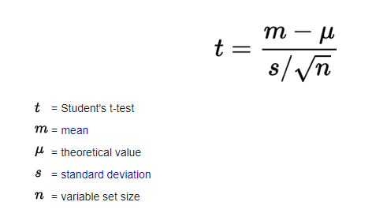

```r
t.test(gpa ~ gender, data=gpa)
```

```
##
##  Welch Two Sample t-test
##
## data:  gpa by gender
## t = 4.7535, df = 10.664, p-value = 0.0006496
## alternative hypothesis: true difference in means between group female and group male is not equal to 0
## 95 percent confidence interval:
##  0.136139 0.372611
## sample estimates:
## mean in group female   mean in group male
##             3.841875             3.587500
```

Note:

In the above t-test, we can observe that it has applied the Welch test. This implies that the assumption of equal variances has not been utilized; instead, it is assumed that they are unequal. This is why “Welch Two Sample t-test” is displayed. use “help(t.test)” to check this information: “var.equal: a logical variable indicating whether to treat the two variances as being equal. If TRUE then the pooled variance is used to estimate the variance otherwise the Welch approximation to the degrees of freedom is used”. Try: t.test(gpa ~ gender, data=gpa, var.equal = T) .

This becomes evident because the **degrees of freedom** from the above t-test do not amount to 30, which is the expected value for a traditional student t-test. The reason for this expectation is that we are comparing the means of two groups of samples, and with 32 observations, we would typically expect the degrees of freedom to be 30:

```
Degrees of Freedom = number of samples - number of parameters.

If you have two groups of samples and want to find a parameter, like the mean, you
have two groups of “n”s to consider (group 1 and group 2).
Degrees of freedom in that case is:

Degrees of Freedom(Two groups): (8(males) + 24(females)) – 2 (two means) = 30 df
```

However, under the Welch test, there is an adjustment made to the degrees of freedom to accommodate the unequal variances.

**Interpreting the t-test result:**

When the means are identical, the difference between them equals zero. In our case, we have calculated means that exhibit a disparity - they are 0.25 apart, and the Welch t-test is probing, in light of the **data’s variability**, whether this mean difference (0.25) is significantly distinct from zero.

The **“t = 4.7535”** indicates that the “0.25” difference translates to ~5 standard deviations away from zero. This is a promising initial indication that the means are indeed not equivalent to zero.

The **confidence interval** is essentially a range of values that encloses the means and standard errors (in this case; encloses the difference in the means). Because the null hypothesis assumes a value of zero, this confidence interval range, which encloses the difference between the means (a difference we have determined to be 0.25), should not contain 0 in order to reject the null hypothesis.

The t-statistics and its associated **p-value** provide us with a probability, indicating how likely it is that we would obtain the observed result of 0.25 or a more extreme result if the null hypothesis were indeed true (which posits an expected value of zero difference in means between group female and group male is not equal to 0).

So, how likely it is to obtain a result of 0.25 under the null hypothesis where zero is expected?

The answer, in this case, is that it is highly unlikely. If the pvalue is sufficiently small (< 0.5), we conclude that it is unlikely we would have observed a result of 0.25 if the null hypothesis (zero difference) were valid. Consequently, we reject the null hypothesis, meaning we dismiss the idea that there is no difference.

Please, **note** that rejecting the null hypothesis does not equate to proving the alternative hypothesis or proving that the difference is indeed 0.25. Collecting data or conducting an experiment doesn’t allow us to prove things conclusively. What we have done is reject the null hypothesis in favor of the notion that the means are not the same.

**Add means to the histogram plot**

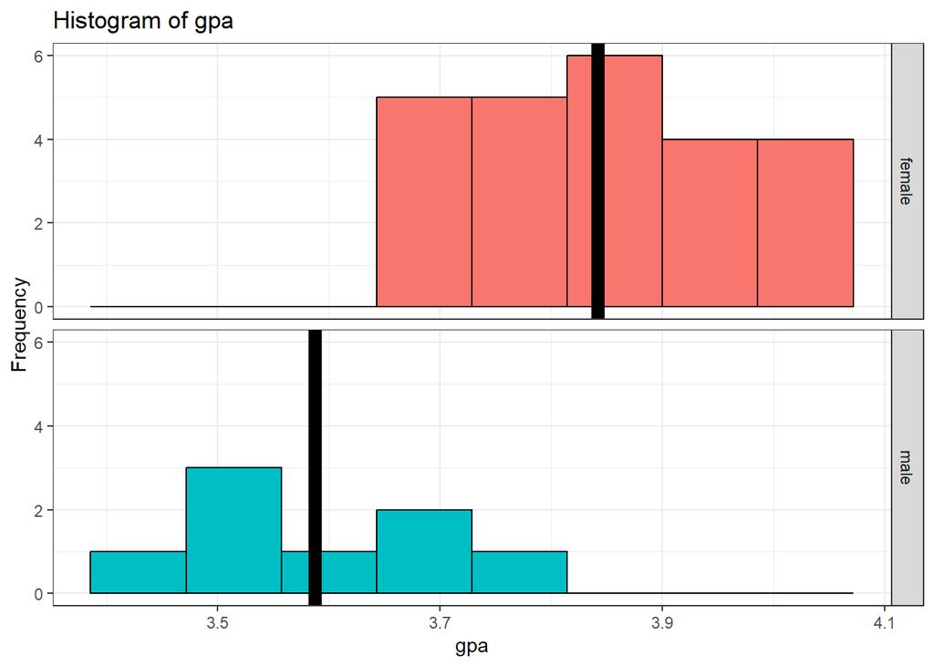

```r
ggplot(data = gpa,aes(x = gpa, fill = gender)) +
  geom_histogram(bins = 8, color = "black") +
  labs(title = "Histogram of gpa", x = "gpa", y = "Frequency")+
  geom_vline(data = gpa_sum_dat, aes(xintercept = mean_gpa, linewidth = 1))+
  facet_grid(gender~.)+
  theme_bw()+
  theme(legend.position="none")
```

Fantastic! Now we can visualize and compare the difference between the means.

### **Exercise**

Work with the “gardens.csv” data set, which provides information about the ozone levels in Garden A and Garden B. Our objective is to assess whether there exists a significant difference between the ozone levels in these two gardens, specifically, whether the mean ozone levels in Garden A and Garden B are statistically distinct.

1. Take a brief look at the data. How many variables are present, and how many observations do we have?
2. Visualize the data and make some assumptions.
3. Calculate the means, standard deviations, and sample sizes for each group.
4. Utilize a histogram to depict the distributions of the samples. It is important to remember that the t-test assumes a normal distribution.
5. Use the t.test function to conduct a two-sample t-test.
6. Articulate the interpretation of each line in the t-test result. Consider the following hints:
- Familiarize yourself with the Welch two-sample t-test.
- Elaborate on what the t-statistic signifies in terms of standard deviations and its relation to the null hypothesis.
- Explain the interpretation of the p-value in the context of the null hypothesis, probability, and the concept of extremeness.
- Reflect on what the confidence interval would contain if there were no significant difference between the gardens. Why is this the case?
- Determine the actual difference between the means.
7. To summarize the results, write a concise text. Your sentence should contain the t-statistic, degrees of freedom (df), and p-value.
8. Create a plot to provide a visual summary of the results. You can use the ggplot() method for presenting means along with error bars (revisit “Data manipulation and advanced plotting” section, to refresh your memory).

Well done! I hope this session have been helpful. Here are the [solutions](https://lizzydapsy.github.io/R-course_materials/Solutions.html) to all the exercises.

**We are now ready for the next stage.**

**Return** to the [main course page](https://lizzydapsy.github.io/R-for-Data-Analysis/README.html) and click on “Basic statistics - chi-square test”.